# Project 1: Digit Classification with KNN and Naive Bayes

David Skarbrevik

W207 Section 4

2/10/2017

In this project, you'll implement your own image recognition system for classifying digits. Read through the code and the instructions carefully and add your own code where indicated. Each problem can be addressed succinctly with the included packages -- please don't add any more. Grading will be based on writing clean, commented code, along with a few short answers.

As always, you're welcome to work on the project in groups and discuss ideas on the course wall, but **please prepare your own write-up (with your own code).**

If you're interested, check out these links related to digit recognition:

Yann Lecun's MNIST benchmarks: http://yann.lecun.com/exdb/mnist/

Stanford Streetview research and data: http://ufldl.stanford.edu/housenumbers/

```python
# This tells matplotlib not to try opening a new window for each plot.
%matplotlib inline

# Import a bunch of libraries.
import time
import itertools # added this library to make a pretty confusion matrix (P5)
import numpy as np
import matplotlib.pyplot as plt
from matplotlib.ticker import MultipleLocator
from sklearn.pipeline import Pipeline
from sklearn.datasets import fetch_mldata
from sklearn.neighbors import KNeighborsClassifier
from sklearn.metrics import confusion_matrix
from sklearn.linear_model import LinearRegression
from sklearn.naive_bayes import BernoulliNB
from sklearn.naive_bayes import MultinomialNB
from sklearn.naive_bayes import GaussianNB
from sklearn.grid_search import GridSearchCV
from sklearn.metrics import classification_report

# Set the randomizer seed so results are the same each time.
np.random.seed(0)
```

Load the data. Notice that we are splitting the data into training, development, and test. We also have a small subset of the training data called mini_train_data and mini_train_labels that you should use in all the experiments below, unless otherwise noted.

```python
# Load the digit data either from mldata.org, or once downloaded to data_home, from disk. The data is about 53MB so this cell
# should take a while the first time your run it.
mnist = fetch_mldata('MNIST original', data_home='~/datasets/mnist')
X, Y = mnist.data, mnist.target

# Rescale grayscale values to [0,1].
X = X / 255.0

# Shuffle the input: create a random permutation of the integers between 0 and the number of data points and apply this
# permutation to X and Y.
# NOTE: Each time you run this cell, you'll re-shuffle the data, resulting in a different ordering.
shuffle = np.random.permutation(np.arange(X.shape[0]))
X, Y = X[shuffle], Y[shuffle]

print ('data shape: ', X.shape)
print ('label shape:', Y.shape)

# Set some variables to hold test, dev, and training data.
test_data, test_labels = X[61000:], Y[61000:]
dev_data, dev_labels = X[60000:61000], Y[60000:61000]
train_data, train_labels = X[:60000], Y[:60000]
mini_train_data, mini_train_labels = X[:1000], Y[:1000]
```

```
data shape:  (70000, 784)
label shape: (70000,)
```

**PROBLEM 1:**

Create a 10x10 grid to visualize 10 examples of each digit. Python hints:

- plt.rc() for setting the colormap, for example to black and white
- plt.subplot() for creating subplots
- plt.imshow() for rendering a matrix
- np.array.reshape() for reshaping a 1D feature vector into a 2D matrix (for rendering)

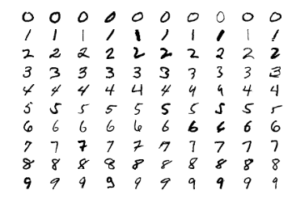

```python
def P1(num_examples=10):

    count=1 # keeps track of which area in XxY matrix to plot in
    plt.rc('image', cmap='binary') # make images appear black and white
    for j in range(10):
        indices = np.where(Y==j)[0][:num_examples]
        for k in indices:
            plt.subplot(10,num_examples,count)
            plt.imshow(np.reshape(X[k], (28, 28)))
            plt.axis("off") # keeps output look clean for a 10x10 matrix
            count += 1

P1(10)
```

**PROBLEM 2:**

Evaluate a K-Nearest-Neighbors model with k = [1,3,5,7,9] using the mini training set. Report accuracy on the dev set. For k=1, show precision, recall, and F1 for each label. Which is the most difficult digit?

- KNeighborsClassifier() for fitting and predicting
- classification_report() for producing precision, recall, F1 results

```python
def P2(k_values):

    for k in k_values:
        kneighbor = KNeighborsClassifier(k) # create the classifier
        kneighbor.fit(mini_train_data, mini_train_labels) # train the classifier
        preds = kneighbor.predict(dev_data) # test the classifier

        if k==1:              # save for reporting later
            preds1 = preds

        correct, total = 0, 0  # for reporting accuracy

        for pred, label in zip(preds, dev_labels):
            if pred == label: correct += 1
            total += 1
        print("Accuracy of Model for k-nearest neighbors =", k, " is ", "%.2f" % (correct/total))

    # give more info on k=1 model
    print("\n")
    print("Diagnoistics for k-nearest neighbor = 1 model:")
    print("\n")
    target_names = ["0","1","2","3","4","5","6","7","8","9"]
    print(classification_report(dev_labels, preds1, target_names=target_names))

k_values = [1,2,3,5,7,9] # trying different neighbor size models
P2(k_values)
```

```
Accuracy of Model for k-nearest neighbors = 1  is  0.89
Accuracy of Model for k-nearest neighbors = 2  is  0.86
Accuracy of Model for k-nearest neighbors = 3  is  0.88
Accuracy of Model for k-nearest neighbors = 5  is  0.87
Accuracy of Model for k-nearest neighbors = 7  is  0.86
Accuracy of Model for k-nearest neighbors = 9  is  0.86


Diagnoistics for k-nearest neighbor = 1 model:


             precision    recall  f1-score   support

          0       0.91      0.98      0.94        99
          1       0.89      1.00      0.94       105
          2       0.99      0.79      0.88       102
          3       0.77      0.87      0.82        86
          4       0.89      0.82      0.85       104
          5       0.93      0.84      0.88        91
          6       0.94      0.96      0.95        98
          7       0.89      0.92      0.90       113
          8       0.94      0.88      0.91        96
          9       0.78      0.82      0.80       106

avg / total       0.89      0.89      0.89      1000
```

ANSWER:

For the k=1 nearest neighbor model, it seems the number "9" is giving our model the most trouble (lowest F1 score at 0.80). Our recall is a little higher than our precision, indicating that our classifier is favoring catching all cases of "9" rather than always being correct in guessing "9".

**PROBLEM 3:**

Using k=1, report dev set accuracy for the training set sizes below. Also, measure the amount of time needed for prediction with each training size.

- time.time() gives a wall clock value you can use for timing operations

```python
def P3(train_sizes, accuracies):

    for j in train_sizes:

        kneighbor = KNeighborsClassifier(1) # create the classifier
        subset_data, subset_labels = X[:j], Y[:j]
        kneighbor.fit(subset_data, subset_labels) # train the classifier
        time1 = time.time()
        preds = kneighbor.predict(dev_data) # test the classifier
        time2 = time.time()
        total_time = time2 - time1
        print("Training size = ", j, " ; Time for prediction = ", "%.2f" % total_time, " seconds.")

        correct, total = 0, 0  # for reporting accuracy

        for pred, label in zip(preds, dev_labels):
            if pred == label: correct += 1
            total += 1
        accuracies = accuracies + [correct/total]
        print("Training size = ", j, " ; Accuracy with KNN-1 is ", "%.2f" % (correct/total))

    return accuracies

train_sizes = [100, 200, 400, 800, 1600, 3200, 6400, 12800, 25000]
accuracies = []
accuracies = P3(train_sizes, accuracies)
```

```
Training size =  100  ; Time for prediction =  0.12  seconds.
Training size =  100  ; Accuracy with KNN-1 is  0.72
Training size =  200  ; Time for prediction =  0.25  seconds.
Training size =  200  ; Accuracy with KNN-1 is  0.79
Training size =  400  ; Time for prediction =  0.50  seconds.
Training size =  400  ; Accuracy with KNN-1 is  0.84
Training size =  800  ; Time for prediction =  1.00  seconds.
Training size =  800  ; Accuracy with KNN-1 is  0.88
Training size =  1600  ; Time for prediction =  2.21  seconds.
Training size =  1600  ; Accuracy with KNN-1 is  0.90
Training size =  3200  ; Time for prediction =  4.55  seconds.
Training size =  3200  ; Accuracy with KNN-1 is  0.93
Training size =  6400  ; Time for prediction =  9.11  seconds.
Training size =  6400  ; Accuracy with KNN-1 is  0.94
Training size =  12800  ; Time for prediction =  18.23  seconds.
Training size =  12800  ; Accuracy with KNN-1 is  0.96
Training size =  25000  ; Time for prediction =  36.28  seconds.
Training size =  25000  ; Accuracy with KNN-1 is  0.97
```

**PROBLEM 4:**

Fit a regression model that predicts accuracy from training size. What does it predict for n=60000? What's wrong with using regression here? Can you apply a transformation that makes the predictions more reasonable?

- Remember that the sklearn fit() functions take an input matrix X and output vector Y. So each input example in X is a vector, even if it contains only a single value.

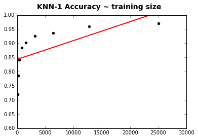

```
Prediction of KNN-1 accuracy given 60,000 training samples = 1.24
```

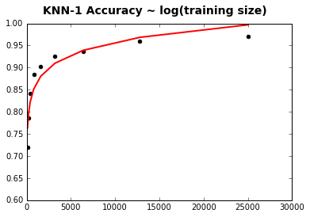

```
Prediction of KNN-1 accuracy given 60,000 training samples = 1.03
```

```python
def P4():

    y_train = accuracies # taken from problem 3 (above)
    x_train = train_sizes # also taken from problem 3

    lm = LinearRegression() # initialize linear model

    # next few steps create a matrix so we can use lm.fit()
    xarray_train = np.asarray(x_train)
    yarray_train = np.asarray(y_train)

    xarray_train = xarray_train.reshape(-1,1)
    yarray_train = yarray_train.reshape(-1,1)

    lm.fit(xarray_train, yarray_train) # estimate coefficients for model


    # plot the simple linear regression
    fig = plt.figure()
    fig.suptitle('KNN-1 Accuracy ~ training size', fontsize=14, fontweight='bold')
    axes = plt.gca()
    axes.set_xlim([0,30000])
    axes.set_ylim([0.6,1])
    plt.scatter(x_train, y_train, color="black")
    plt.plot(x_train, lm.predict(xarray_train), color="red", linewidth=2)
    plt.show()

    print("Prediction of KNN-1 accuracy given 60,000 training samples =", "%.2f" % (lm.predict(60000))[0][0])


    # log transformation to better account for the type of data in this model
    lm.fit(np.log(xarray_train), yarray_train)


    # plot the transformed linear regression
    fig = plt.figure()
    fig.suptitle('KNN-1 Accuracy ~ log(training size)', fontsize=14, fontweight='bold')
    axes = plt.gca()
    axes.set_xlim([0,30000])
    axes.set_ylim([0.6,1])
    plt.scatter(x_train, y_train, color="black")
    plt.plot(x_train, lm.predict(np.log(xarray_train)), color="red", linewidth=2)
    plt.show()

    print("Prediction of KNN-1 accuracy given 60,000 training samples =", "%.2f" % (lm.predict(np.log(60000)))[0][0])

P4()
```

ANSWER:

The linear regression model predicts an accuracy of 1.24 for a training size of 60,000 samples. Obviously no model can have higher accuracy than 1.00, so this linear estimation of accuracy is not appropriate.

After applying a logarithmic transformation to the independent variable (training size) we see the regression better fitting our data, however the regression line still predicts that a training size of 60,000 will result in a model accuracy of 1.03 (above 1).

**PROBLEM 5:**

Fit a 1-NN and output a confusion matrix for the dev data. Use the confusion matrix to identify the most confused pair of digits, and display a few example mistakes.

- confusion_matrix() produces a confusion matrix

```
Confusion matrix, without normalization
[[ 97   0   0   0   0   0   2   0   0   0]
 [  0 105   0   0   0   0   0   0   0   0]
 [  4   4  81   4   0   0   0   4   3   2]
 [  1   0   0  75   0   3   0   3   1   3]
 [  0   2   0   0  85   0   3   0   0  14]
 [  2   0   0   9   0  76   0   1   1   2]
 [  1   1   1   0   1   0  94   0   0   0]
 [  1   4   0   1   1   0   0 104   0   2]
 [  0   2   0   5   0   2   1   0  84   2]
 [  1   0   0   3   9   1   0   5   0  87]]
```

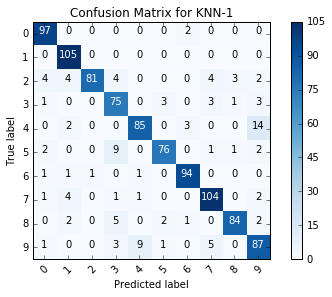

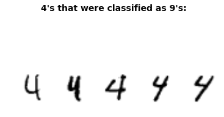

```python
# NOTE: "plot_confustion_matrix" function taken directly from scikit-learn.org

def plot_confusion_matrix(cm, classes,
                          normalize=False,
                          title='Confusion matrix',
                          cmap=plt.cm.Blues):
    """
    This function prints and plots the confusion matrix.
    Normalization can be applied by setting `normalize=True`.
    """
    plt.imshow(cm, interpolation='nearest', cmap=cmap)
    plt.title(title)
    plt.colorbar()
    tick_marks = np.arange(len(classes))
    plt.xticks(tick_marks, classes, rotation=45)
    plt.yticks(tick_marks, classes)

    if normalize:
        cm = cm.astype('float') / cm.sum(axis=1)[:, np.newaxis]
        print("Normalized confusion matrix")
    else:
        print('Confusion matrix, without normalization')

    print(cm)

    thresh = cm.max() / 2.
    for i, j in itertools.product(range(cm.shape[0]), range(cm.shape[1])):
        plt.text(j, i, cm[i, j],
                 horizontalalignment="center",
                 color="white" if cm[i, j] > thresh else "black")

    plt.tight_layout()
    plt.ylabel('True label')
    plt.xlabel('Predicted label')

def P5():
    kneighbor = KNeighborsClassifier(1) # create the classifier
    kneighbor.fit(mini_train_data, mini_train_labels) # train the classifier
    preds = kneighbor.predict(dev_data) # test the classifier

    target_names = ["0","1","2","3","4","5","6","7","8","9"]
    conf_matrix = confusion_matrix(dev_labels, preds)
    np.set_printoptions(precision=2)

    plt.figure()
    plot_confusion_matrix(conf_matrix, classes=target_names,
                          title="Confusion Matrix for KNN-1")

    # KNN-1 is having issues with classifying "4"s as "9"s

    count_plot = 1 #for organizing plots below
    count_loop = 0 #for indexing loop
    plt.rc("image", cmap="binary") #black and white plot output
    plt.figure()
    plt.suptitle("4's that were classified as 9's:",
                 fontsize=14, fontweight="bold")
    for pred, label in zip(preds, dev_labels):
        if pred ==9 and label==4 and count_plot < 6:
            plt.subplot(1,5,count_plot)
            plt.imshow(np.reshape(dev_data[count_loop], (28,28)))
            plt.axis("off")
            count_plot += 1
        count_loop += 1
P5()
```

ANSWER:

Previously, we saw that our KNN-1 model had the most issues with classifying "9". The confusion matrix above reiterates this issue but shows us that the model is often incorrectly labeling "4"s as "9"s. This is understandable since people often write "4"s with a closed loop similar to a "9". We see this illustrated in the 5 mis-classified examples above.

**PROBLEM 6:**

A common image processing technique is to smooth an image by blurring. The idea is that the value of a particular pixel is estimated as the weighted combination of the original value and the values around it. Typically, the blurring is Gaussian -- that is, the weight of a pixel's influence is determined by a Gaussian function over the distance to the relevant pixel.

Implement a simplified Gaussian blur by just using the 8 neighboring pixels: the smoothed value of a pixel is a weighted combination of the original value and the 8 neighboring values. Try applying your blur filter in 3 ways:

- preprocess the training data but not the dev data
- preprocess the dev data but not the training data
- preprocess both training and dev data

Note that there are Guassian blur filters available, for example in scipy.ndimage.filters. You're welcome to experiment with those, but you are likely to get the best results with the simplified version I described above.

```
KNN-1 with no pre-processing:


             precision    recall  f1-score   support

          0       0.91      0.98      0.94        99
          1       0.89      1.00      0.94       105
          2       0.99      0.79      0.88       102
          3       0.77      0.87      0.82        86
          4       0.89      0.82      0.85       104
          5       0.93      0.84      0.88        91
          6       0.94      0.96      0.95        98
          7       0.89      0.92      0.90       113
          8       0.94      0.88      0.91        96
          9       0.78      0.82      0.80       106

avg / total       0.89      0.89      0.89      1000



Preprocess just training data:


             precision    recall  f1-score   support

          0       0.02      0.01      0.01        99
          1       0.00      0.01      0.00       105
          2       0.00      0.00      0.00       102
          3       0.00      0.00      0.00        86
          4       0.02      0.03      0.02       104
          5       0.26      0.19      0.22        91
          6       0.00      0.00      0.00        98
          7       0.07      0.03      0.04       113
          8       0.00      0.00      0.00        96
          9       0.00      0.00      0.00       106

avg / total       0.04      0.03      0.03      1000
```

```
Preprocess just dev data:


             precision    recall  f1-score   support

          0       0.00      0.00      0.00        99
          1       0.10      1.00      0.19       105
          2       0.00      0.00      0.00       102
          3       0.00      0.00      0.00        86
          4       0.00      0.00      0.00       104
          5       0.00      0.00      0.00        91
          6       0.00      0.00      0.00        98
          7       0.00      0.00      0.00       113
          8       0.00      0.00      0.00        96
          9       0.00      0.00      0.00       106

avg / total       0.01      0.10      0.02      1000



Preprocess both training and dev data:


             precision    recall  f1-score   support

          0       0.93      0.98      0.96        99
          1       0.76      1.00      0.86       105
          2       1.00      0.76      0.87       102
          3       0.76      0.83      0.79        86
          4       0.85      0.84      0.84       104
          5       0.89      0.81      0.85        91
          6       0.94      0.96      0.95        98
          7       0.86      0.87      0.86       113
          8       0.94      0.79      0.86        96
          9       0.78      0.78      0.78       106

avg / total       0.87      0.86      0.86      1000
```

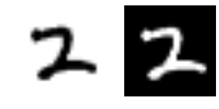

```python
def P6():

    # gaussian blur for training data
    gauss_blur = np.exp(-(mini_train_data**2/8.0))
    mini_train_gauss = gauss_blur/gauss_blur.sum()

    # gaussian blur for development data
    gauss_blur = np.exp(-(dev_data**2/8.0))
    dev_data_gauss = gauss_blur/gauss_blur.sum()


    kneighbor = KNeighborsClassifier(1) # create the classifier


    # original KNN-1 model
    kneighbor.fit(mini_train_data, mini_train_labels)
    preds = kneighbor.predict(dev_data)
    print("\n")
    print("KNN-1 with no pre-processing:")
    print("\n")
    target_names = ["0","1","2","3","4","5","6","7","8","9"]
    print(classification_report(dev_labels, preds, target_names=target_names))

    # pre-processing the training data
    kneighbor.fit(mini_train_gauss, mini_train_labels)
    preds = kneighbor.predict(dev_data)
    print("\n")
    print("Preprocess just training data:")
    print("\n")
    target_names = ["0","1","2","3","4","5","6","7","8","9"]
    print(classification_report(dev_labels, preds, target_names=target_names))

    # pre-processing the dev data
    kneighbor.fit(mini_train_data, mini_train_labels)
    preds = kneighbor.predict(dev_data_gauss)
    print("\n")
    print("Preprocess just dev data:")
    print("\n")
    target_names = ["0","1","2","3","4","5","6","7","8","9"]
    print(classification_report(dev_labels, preds, target_names=target_names))

     # pre-processing both training and dev data
    kneighbor.fit(mini_train_gauss, mini_train_labels)
    preds = kneighbor.predict(dev_data_gauss)
    print("\n")
    print("Preprocess both training and dev data:")
    print("\n")
    target_names = ["0","1","2","3","4","5","6","7","8","9"]
    print(classification_report(dev_labels, preds, target_names=target_names))

    # let's see if we can see a visual difference with the gaussian blur

    plt.rc('image', cmap='binary') # make images appear black and white

    plt.subplot(1,2,1)
    plt.imshow(np.reshape(mini_train_data[2], (28, 28)))
    plt.axis("off") # keeps output look clean for a 10x10 matrix

    plt.subplot(1,2,2)
    plt.imshow(np.reshape(mini_train_gauss[2], (28, 28)))
    plt.axis("off") # keeps output look clean for a 10x10 matrix

P6()
```

**PROBLEM 7:**

Fit a Naive Bayes classifier and report accuracy on the dev data. Remember that Naive Bayes estimates P(feature|label). While sklearn can handle real-valued features, let's start by mapping the pixel values to either 0 or 1. You can do this as a preprocessing step, or with the binarize argument. With binary-valued features, you can use BernoulliNB. Next try mapping the pixel values to 0, 1, or 2, representing white, grey, or black. This mapping requires MultinomialNB. Does the multi-class version improve the results? Why or why not?

```python
def P7():

    # first do NB with binary data

    binary_train_data = np.copy(mini_train_data)

    for i in range(len(mini_train_data)):
        for j in range(len(mini_train_data[0])):
            if (mini_train_data[i][j] < 0.3):
                binary_train_data[i][j] = 0.0
            else:
                binary_train_data[i][j] = 1.0


    bernoulli_model = BernoulliNB()
    bernoulli_model.fit(binary_train_data, mini_train_labels)
    bernoulli_model.score(dev_data, dev_labels)

    # now try NB with three bins instead of two

    multi_label_train_data = np.copy(mini_train_data)

    mini_train_data[0][0]
    multi_label_train_data[0][0] = 1.0

    for i in range(len(mini_train_data)):
        for j in range(len(mini_train_data[0])):
            if mini_train_data[i][j] < 0.2:
                multi_label_train_data[i][j] = 0.0
            elif mini_train_data[i][j] >= 0.2 and mini_train_data[i][j] <= 0.5:
                multi_label_train_data[i][j] = 1.0
            else:
                multi_label_train_data[i][j] = 2.0


    bernoulli_model = BernoulliNB()
    bernoulli_model.fit(multi_label_train_data, mini_train_labels)
    bernoulli_model.score(dev_data, dev_labels)

P7()
```